# Predict handwritten digits

| **Use scikit-learn to predict hand-written digits** |  |
| --- | --- |

This notebook demonstrates how to utilize the [watson-machine-learning-client](https://pypi.python.org/pypi/watson-machine-learning-client-V4) package in order to save, deploy, and score a predictive model.

You will use the sample data set of hand-written digit images, `sklearn.datasets.load_digits`, which is available in scikit-learn to recognize hand-written digits. The notebook uses `scikit-learn 0.20` and `watson-machine-learning-client-V4`.

Some familiarity with Python is helpful. This notebook is compatible with CP4D 2.5 and Python 3.6.

## Learning goals

In this notebook, you will learn how to:

- Load a sample data set from `scikit-learn`.
- Explore data.
- Split data for training and evaluation.
- Create a scikit-learn machine learning pipeline.
- Train and evaluate a model.
- Store the model in the Watson Machine Learning (WML) repository.
- Deploy the model for online scoring in the Watson Machine Learning (WML) repository.
- Score test records.
1. Setting up
2. Load and explore data
3. Create a scikit-learn model  
   3.1 Split data  
   3.2 Create a scikit-learn machine learning pipeline  
   3.3 Train a model
4. Save, load, and delete a model in the WML repository  
   4.1 Authenticate  
   4.2 Save the model in the WML repository  
   4.3 Load a model from the WML repository  
   4.4 Delete a model from the WML repository
5. Deploy and score data in the WML repository  
   5.1 Create an online deployment for the published model  
   5.2 Get deployments  
   5.3 Score data  
   5.4 Delete the deployment  
   5.5 Delete the model
6. Summary and next steps

## 1. Set up the environment

To get started on CP4D, find documentation on installion and set up [here](https://www.ibm.com/support/knowledgecenter/SSQNUZ_current/wsj/getting-started/welcome-main.html).

- Configure your python environment:
  - Python 3.6
  - scikit-learn 0.20
  - watson-machine-learning-client-V4

## 2. Load and explore data

In this section, you load the data from scikit-learn sample data sets and perform basic exploratory data analysis (EDA).

1. To avoid re-installation when re-running the notebook, try running your notebooks in custom environments. To find out more about setting up custom environments, see [here](https://www.ibm.com/support/knowledgecenter/SSQNUZ_current/wsj/analyze-data/customize-envs.html).  
2. To simply hide the output of pip install instead, use `-q` after `!pip install`.

```python
!pip install --upgrade scikit-learn==0.20.4
```

```python
# Load the data.
import sklearn
from sklearn import datasets

# Description of the Digits Data set.
digits = datasets.load_digits()
print(digits.DESCR)
```

```
.. _digits_dataset:

Optical recognition of handwritten digits dataset
--------------------------------------------------

**Data Set Characteristics:**

    :Number of Instances: 5620
    :Number of Attributes: 64
    :Attribute Information: 8x8 image of integer pixels in the range 0..16.
    :Missing Attribute Values: None
    :Creator: E. Alpaydin (alpaydin '@' boun.edu.tr)
    :Date: July; 1998

This is a copy of the test set of the UCI ML hand-written digits datasets
http://archive.ics.uci.edu/ml/datasets/Optical+Recognition+of+Handwritten+Digits

The data set contains images of hand-written digits: 10 classes where
each class refers to a digit.

Preprocessing programs made available by NIST were used to extract
normalized bitmaps of handwritten digits from a preprinted form. From a
total of 43 people, 30 contributed to the training set and different 13
to the test set. 32x32 bitmaps are divided into nonoverlapping blocks of
4x4 and the number of on pixels are counted in each block. This generates
an input matrix of 8x8 where each element is an integer in the range
0..16. This reduces dimensionality and gives invariance to small
distortions.

For info on NIST preprocessing routines, see M. D. Garris, J. L. Blue, G.
T. Candela, D. L. Dimmick, J. Geist, P. J. Grother, S. A. Janet, and C.
L. Wilson, NIST Form-Based Handprint Recognition System, NISTIR 5469,
1994.

.. topic:: References

  - C. Kaynak (1995) Methods of Combining Multiple Classifiers and Their
    Applications to Handwritten Digit Recognition, MSc Thesis, Institute of
    Graduate Studies in Science and Engineering, Bogazici University.
  - E. Alpaydin, C. Kaynak (1998) Cascading Classifiers, Kybernetika.
  - Ken Tang and Ponnuthurai N. Suganthan and Xi Yao and A. Kai Qin.
    Linear dimensionalityreduction using relevance weighted LDA. School of
    Electrical and Electronic Engineering Nanyang Technological University.
    2005.
  - Claudio Gentile. A New Approximate Maximal Margin Classification
    Algorithm. NIPS. 2000.
```

The sample data set consists of 8x8 pixel images of hand-written digits.

```python
digits.data.shape
```

```
(1797, 64)
```

Display the first digit data and label using **data** and **target**. The hand-written digit shown below is an 8x8 pixel image represented by an array.

```python
print(digits.data[0].reshape((8, 8)))
```

```
[[ 0.  0.  5. 13.  9.  1.  0.  0.]
 [ 0.  0. 13. 15. 10. 15.  5.  0.]
 [ 0.  3. 15.  2.  0. 11.  8.  0.]
 [ 0.  4. 12.  0.  0.  8.  8.  0.]
 [ 0.  5.  8.  0.  0.  9.  8.  0.]
 [ 0.  4. 11.  0.  1. 12.  7.  0.]
 [ 0.  2. 14.  5. 10. 12.  0.  0.]
 [ 0.  0.  6. 13. 10.  0.  0.  0.]]
```

```python
digits.target[0]
```

```
0
```

```python
!pip install --upgrade matplotlib
```

```python
import matplotlib.pyplot as plt
import numpy as np
```

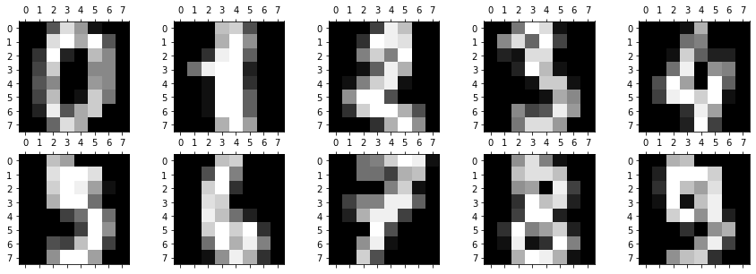

```python
# Visualize some digits from the data set.
f, ((ax1, ax2, ax3, ax4, ax5), (ax6, ax7, ax8, ax9, ax10)) = plt.subplots(2, 5, figsize=(15,5))
ax = [ax1, ax2, ax3, ax4, ax5, ax6, ax7, ax8, ax9, ax10]

for i in range (len(ax)):
    plt.gray()
    ax[i].matshow(digits.images[i])
```

```python
# Labels for the written digits displayed above.
digits.target[:10]
```

```
array([0, 1, 2, 3, 4, 5, 6, 7, 8, 9])
```

In the next step, count the data examples.

```python
# Calculate the number of samples.
samples_count = len(digits.images)

print('Number of samples: ' + str(samples_count))
```

```
Number of samples: 1797
```

## 3. Create a scikit-learn model

In this section you learn how to:

- 3.1 Split data
- 3.2 Create a scikit-learn machine learning pipeline
- 3.3 Train a model

### 3.1 Split data

In this subsection you will split your data into:

- Train data set
- Test data set
- Score data sets

```python
# Split the data into data sets and display the number of records for each data set.
train_data = digits.data[: int(0.7*samples_count)]
train_labels = digits.target[: int(0.7*samples_count)]

test_data = digits.data[int(0.7*samples_count): int(0.9*samples_count)]
test_labels = digits.target[int(0.7*samples_count): int(0.9*samples_count)]

score_data = digits.data[int(0.9*samples_count): ]

print('Number of training records: ' + str(len(train_data)))
print('Number of testing records : ' + str(len(test_data)))
print('Number of scoring records : ' + str(len(score_data)))
```

```
Number of training records: 1257
Number of testing records : 360
Number of scoring records : 180
```

Your data has been successfully split into three data sets:

- The train data set, which is the largest group, is used for training.
- The test data set is used for model evaluation and to test the assumptions of the model.
- The score data set is used for scoring.

### 3.2 Create a scikit-learn machine learning pipeline

In this section, you will create a scikit-learn machine learning pipeline and then train the model.

First, import the scikit-learn machine learning modules that are needed in the subsequent steps.

```python
# Import scikit-learn packages.
from sklearn.pipeline import Pipeline
from sklearn import preprocessing
from sklearn import svm, metrics
```

Standardize the features by removing the mean and scaling to unit variance.

```python
scaler = preprocessing.StandardScaler()
```

Next, define the estimators you want to use for classification. The following example uses Support Vector Machines (SVM) with the radial basis function (used for non-linear data) as the kernel.

```python
clf = svm.SVC(kernel='rbf', gamma='auto')
```

Build the pipeline. A pipeline consists of transformer and an estimator.

```python
pipeline = Pipeline([('scaler', scaler), ('svc', clf)])
```

### 3.3 Train a model

Now, you can use the **pipeline** and **train data** you defined previously to train your SVM model.

```python
model = pipeline.fit(train_data, train_labels)
```

Use **test data** to generate an evaluation report to check your **model quality**.

```python
# Evaluate your model.
predicted = model.predict(test_data)

print('Evaluation report: \n\n%s' % metrics.classification_report(test_labels, predicted))
```

```
Evaluation report:

              precision    recall  f1-score   support

           0       1.00      0.97      0.99        37
           1       0.97      0.97      0.97        34
           2       1.00      0.97      0.99        36
           3       1.00      0.94      0.97        35
           4       0.78      0.97      0.87        37
           5       0.97      0.97      0.97        38
           6       0.97      0.86      0.91        36
           7       0.92      0.97      0.94        35
           8       0.91      0.89      0.90        35
           9       0.97      0.92      0.94        37

   micro avg       0.94      0.94      0.94       360
   macro avg       0.95      0.94      0.95       360
weighted avg       0.95      0.94      0.95       360
```

You can tune your model, or try to create classification models to achieve better accuracy. For the simplicity purpose of this example, the tuning and model selections are omitted.

## 4. Save, load, and delete a model in the WML repository

In this section, you will learn how to use the `watson-machine-learning-client` package to manage your model in the WML repository.

- 4.1 Set up the WML instance
- 4.2 Save the model in the WML repository
- 4.3 Load a model from the WML repository
- 4.4 Delete a model from the WML repository

You can find more information about the watson-machine-learning-client [here](https://wml-api-pyclient-dev-v4.mybluemix.net/).

### 4.1 Authenticate

First, import the required modules.

```python
!pip install --upgrade watson-machine-learning-client-V4
```

```python
from watson_machine_learning_client import WatsonMachineLearningAPIClient
```

**Authenticate the Python client on CP4D.**

To find your authentication information (your credentials) follow the steps provided here in the [Documentation](https://www.ibm.com/support/knowledgecenter/SSQNUZ_current/wsj/analyze-data/ml-authentication-local.html).

**Action**: Enter your credentials in the following cell.

```python
# Enter your credentials here.
import sys,os,os.path
token = os.environ['USER_ACCESS_TOKEN']

wml_credentials = {
    "token": "",
    "instance_id" : "wml_local",
    "url": "",
    "version": "2.5.0"
}
```

#### Instantiate the WML API client object.

```python
client = WatsonMachineLearningAPIClient(wml_credentials)
```

### 4.2 Save the model in the WML repository

Create the model metadata to store in the WML repository. You can obtain the space UID (one of the MetaNames in the model metadata) by using the following cells.

You can create your own [deployment space](https://www.ibm.com/support/knowledgecenter/SSQNUZ_current/wsj/analyze-data/ml-spaces_local.html) by selecting **Analytics deployments** from the Navigation Menu on the top left of this page.

Alternatively you can create a deployment using the code in the following cell. The cell is not executable cell at this stage, but you can enter the name of your space in the metadata and use it if needed.

space_details = client.spaces.store(meta_props={client.spaces.ConfigurationMetaNames.NAME: "YOUR DEPLOYMENT SPACE"}) space_uid = client.spaces.get_uid(space_details) print("Space UID = " + space_uid)

```python
# Obtain the UId of your space
def guid_from_space_name(client, space_name):
    instance_details = client.service_instance.get_details()
    space = client.spaces.get_details()
    return(next(item for item in space['resources'] if item['entity']["name"] == space_name)['metadata']['guid'])
```

**Action:** Enter the name of your deployment space in the code below: `space_uid = guid_from_space_name(client, 'YOUR DEPLOYMENT SPACE')`.

```python
# Enter the name of your deployment space here:
space_uid = guid_from_space_name(client, 'YOUR DEPLOYMENT SPACE')
print("Space UID = " + space_uid)
```

```
Space UID = e4d55ac7-b191-46ea-9557-e9de05eb2151
```

Setting the default space is mandatory for CP4D. You can set this using the cell below.

```python
client.set.default_space(space_uid)
```

```
'SUCCESS'
```

You can see the stored predefined runtimes here.

```python
client.runtimes.list(pre_defined=True)
```

```
--------------------------  --------------------------  ------------------------  --------
GUID                        NAME                        CREATED                   PLATFORM
do_12.9                     do_12.9                     2019-12-13T04:53:28.418Z  do
pmml_4.3                    pmml_4.3                    2019-12-13T04:53:28.268Z  pmml
pmml_4.2.1                  pmml_4.2.1                  2019-12-13T04:53:28.198Z  pmml
pmml_4.2                    pmml_4.2                    2019-12-13T04:53:28.129Z  pmml
pmml_4.1                    pmml_4.1                    2019-12-13T04:53:28.032Z  pmml
pmml_4.0                    pmml_4.0                    2019-12-13T04:53:27.952Z  pmml
pmml_3.2                    pmml_3.2                    2019-12-13T04:53:27.877Z  pmml
pmml_3.1                    pmml_3.1                    2019-12-13T04:53:27.777Z  pmml
pmml_3.0                    pmml_3.0                    2019-12-13T04:53:27.709Z  pmml
ai-function_0.1-py3.6       ai-function_0.1-py3.6       2019-12-13T04:53:27.600Z  python
ai-function_0.1-py3         ai-function_0.1-py3         2019-12-13T04:53:27.427Z  python
hybrid_0.2                  hybrid_0.2                  2019-12-13T04:53:27.259Z  hybrid
hybrid_0.1                  hybrid_0.1                  2019-12-13T04:53:27.128Z  hybrid
xgboost_0.82-py3.6          xgboost_0.82-py3.6          2019-12-13T04:53:27.052Z  python
xgboost_0.82-py3            xgboost_0.82-py3            2019-12-13T04:53:26.966Z  python
xgboost_0.80-py3.6          xgboost_0.80-py3.6          2019-12-13T04:53:26.881Z  python
xgboost_0.80-py3            xgboost_0.80-py3            2019-12-13T04:53:26.760Z  python
xgboost_0.6-py3             xgboost_0.6-py3             2019-12-13T04:53:26.651Z  python
spss-modeler_18.2           spss-modeler_18.2           2019-12-13T04:53:26.555Z  spss
spss-modeler_18.1           spss-modeler_18.1           2019-12-13T04:53:26.453Z  spss
spss-modeler_17.1           spss-modeler_17.1           2019-12-13T04:53:26.317Z  spss
scikit-learn_0.20-py3.6     scikit-learn_0.20-py3.6     2019-12-13T04:53:26.226Z  python
scikit-learn_0.20-py3       scikit-learn_0.20-py3       2019-12-13T04:53:26.109Z  python
scikit-learn_0.19-py3.6     scikit-learn_0.19-py3.6     2019-12-13T04:53:25.897Z  python
scikit-learn_0.19-py3       scikit-learn_0.19-py3       2019-12-13T04:53:25.785Z  python
scikit-learn_0.17-py3       scikit-learn_0.17-py3       2019-12-13T04:53:25.679Z  python
spark-mllib_2.3             spark-mllib_2.3             2019-12-13T04:53:25.587Z  spark
spark-mllib_2.2             spark-mllib_2.2             2019-12-13T04:53:25.458Z  spark
tensorflow_1.14-py3.6       tensorflow_1.14-py3.6       2019-12-13T04:53:25.383Z  python
tensorflow_1.13-py3.6       tensorflow_1.13-py3.6       2019-12-13T04:53:25.284Z  python
tensorflow_1.11-py3.6       tensorflow_1.11-py3.6       2019-12-13T04:53:25.227Z  python
tensorflow_1.13-py3         tensorflow_1.13-py3         2019-12-13T04:53:25.111Z  python
tensorflow_1.13-py2         tensorflow_1.13-py2         2019-12-13T04:53:25.037Z  python
tensorflow_0.11-horovod     tensorflow_0.11-horovod     2019-12-13T04:53:24.861Z  native
tensorflow_1.11-py3         tensorflow_1.11-py3         2019-12-13T04:53:24.798Z  python
tensorflow_1.10-py3         tensorflow_1.10-py3         2019-12-13T04:53:24.731Z  python
tensorflow_1.10-py2         tensorflow_1.10-py2         2019-12-13T04:53:24.651Z  python
tensorflow_1.9-py3          tensorflow_1.9-py3          2019-12-13T04:53:24.571Z  python
tensorflow_1.9-py2          tensorflow_1.9-py2          2019-12-13T04:53:24.439Z  python
tensorflow_1.8-py3          tensorflow_1.8-py3          2019-12-13T04:53:24.351Z  python
tensorflow_1.8-py2          tensorflow_1.8-py2          2019-12-13T04:53:24.280Z  python
tensorflow_1.7-py3          tensorflow_1.7-py3          2019-12-13T04:53:24.185Z  python
tensorflow_1.7-py2          tensorflow_1.7-py2          2019-12-13T04:53:24.093Z  python
tensorflow_1.6-py3          tensorflow_1.6-py3          2019-12-13T04:53:23.996Z  python
tensorflow_1.6-py2          tensorflow_1.6-py2          2019-12-13T04:53:23.892Z  python
tensorflow_1.5-py2-ddl      tensorflow_1.5-py2-ddl      2019-12-13T04:53:23.808Z  python
tensorflow_1.5-py3-horovod  tensorflow_1.5-py3-horovod  2019-12-13T04:53:23.743Z  python
tensorflow_1.5-py3.6        tensorflow_1.5-py3.6        2019-12-13T04:53:23.663Z  python
tensorflow_1.5-py3          tensorflow_1.5-py3          2019-12-13T04:53:23.570Z  python
tensorflow_1.5-py2          tensorflow_1.5-py2          2019-12-13T04:53:23.483Z  python
--------------------------  --------------------------  ------------------------  --------
Note: Only first 50 records were displayed. To display more use 'limit' parameter.
```

```python
# Model Metadata.
meta_props={
    client.repository.ModelMetaNames.NAME: "Digits prediction model",
    client.repository.ModelMetaNames.RUNTIME_UID: "scikit-learn_0.20-py3.6",
    client.repository.ModelMetaNames.TYPE: "scikit-learn_0.20",
    client.repository.ModelMetaNames.SPACE_UID: space_uid
}
```

You need the model UID to create the deployment. You can extract the model UID from the saved model details and use it in the next section to create the deployment.

```python
# Create the model artifact.
model_artifact = client.repository.store_model(model,
                                                   meta_props=meta_props,
                                                   training_data=train_data,
                                                   training_target=train_labels)
model_uid = client.repository.get_model_uid(model_artifact)
print("Model UID = " + model_uid)
```

```
Model UID = 1eba65f1-b6b8-41b3-9df0-b2137ff4a92b
```

#### Get information about a specific model in the WML repository

Get the saved model metadata from WML.

```python
# Details about the model.
model_details = client.repository.get_details(model_uid)
from pprint import pprint
pprint(model_details)
```

```
{'entity': {'content_status': {'state': 'persisted'},
            'label_column': 'l1',
            'name': 'Digits prediction model',
            'runtime': {'href': '/v4/runtimes/scikit-learn_0.20-py3.6'},
            'space': {'href': '/v4/spaces/e4d55ac7-b191-46ea-9557-e9de05eb2151'},
            'training_data_references': [{'connection': {'access_key_id': 'not_applicable',
                                                         'endpoint_url': 'not_applicable',
                                                         'secret_access_key': 'not_applicable'},
                                          'location': {'bucket': 'not_applicable'},
                                          'schema': {'fields': [{'name': 'f0',
                                                                 'type': 'float'},
                                                                {'name': 'f1',
                                                                 'type': 'float'},
                                                                {'name': 'f2',
                                                                 'type': 'float'},
                                                                {'name': 'f3',
                                                                 'type': 'float'},
                                                                {'name': 'f4',
                                                                 'type': 'float'},
                                                                {'name': 'f5',
                                                                 'type': 'float'},
                                                                {'name': 'f6',
                                                                 'type': 'float'},
                                                                {'name': 'f7',
                                                                 'type': 'float'},
                                                                {'name': 'f8',
                                                                 'type': 'float'},
                                                                {'name': 'f9',
                                                                 'type': 'float'},
                                                                {'name': 'f10',
                                                                 'type': 'float'},
                                                                {'name': 'f11',
                                                                 'type': 'float'},
                                                                {'name': 'f12',
                                                                 'type': 'float'},
                                                                {'name': 'f13',
                                                                 'type': 'float'},
                                                                {'name': 'f14',
                                                                 'type': 'float'},
                                                                {'name': 'f15',
```

[output cut: 92 more lines]

```
                                                                 'type': 'float'},
                                                                {'name': 'f62',
                                                                 'type': 'float'},
                                                                {'name': 'f63',
                                                                 'type': 'float'}],
                                                     'id': '1',
                                                     'type': 'ndarray'},
                                          'type': 'fs'}],
            'type': 'scikit-learn_0.20'},
 'metadata': {'created_at': '2020-01-10T21:44:58.002Z',
              'guid': '1eba65f1-b6b8-41b3-9df0-b2137ff4a92b',
              'href': '/v4/models/1eba65f1-b6b8-41b3-9df0-b2137ff4a92b?space_id=e4d55ac7-b191-46ea-9557-e9de05eb2151',
              'id': '1eba65f1-b6b8-41b3-9df0-b2137ff4a92b',
              'modified_at': '2020-01-10T21:45:00.002Z',
              'owner': '1000330999'}}
```

#### Get the information of all the models in the WML repository

```python
# Display a list of all the models.
models_details = client.repository.list_models()
```

```
------------------------------------  -----------------------  ------------------------  -----------------
GUID                                  NAME                     CREATED                   TYPE
1eba65f1-b6b8-41b3-9df0-b2137ff4a92b  Digits prediction model  2020-01-10T21:44:58.002Z  scikit-learn_0.20
------------------------------------  -----------------------  ------------------------  -----------------
```

### 4.3 Load a model from the WML repository

In this subsection, you will learn how to load a saved model from the WML repository.

```python
loaded_model = client.repository.load(model_uid)
```

Make test predictions to check that the model has been loaded correctly.

```python
test_predictions = loaded_model.predict(test_data[:10])
```

```python
# The predictions made by the model.
print(test_predictions)
```

```
[4 0 5 3 6 9 6 4 7 5]
```

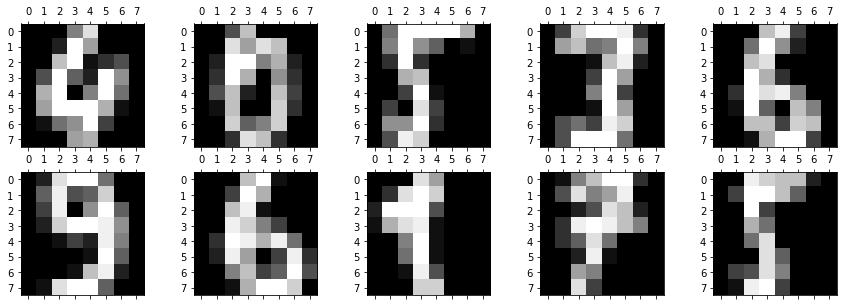

```python
# Visualize the test set images used for the prediction.
f, ((ax1, ax2, ax3, ax4, ax5), (ax6, ax7, ax8, ax9, ax10)) = plt.subplots(2, 5, figsize=(15,5))
ax = [ax1, ax2, ax3, ax4, ax5, ax6, ax7, ax8, ax9, ax10]

for i in range (len(ax)):
    plt.gray()
    ax[i].matshow(test_data[i].reshape((8, 8)))
```

```python
# The correct labels for the digits above.
test_labels[:10]
```

```
array([4, 0, 5, 3, 6, 9, 6, 1, 7, 5])
```

As you can see, you are able to make predictions which means that the model has loaded correctly. You have now learned how save and load the model in/from the WML repository.

### 4.4 Delete a model from the WML repository

The code in the following cell deletes a published model from the WML repository. The code is not executable at this stage because you still need the model for deployment.

client.repository.delete(model_uid)

## 5. Deploy and score data in the WML repository

In this section, you will learn how to use the WML API client to perform online scoring and score a test data record.

- 5.1 Create an online deployment for the published model
- 5.2 Get deployments
- 5.3 Score data
- 5.4 Delete the deployment
- 5.5 Delete the model

### 5.1 Create an online deployment for the published model

Now, you can create a deployment, *Deployment of scikit handwritten digits model*.

```python
# Deployment metadata.
deploy_meta = {
    client.deployments.ConfigurationMetaNames.NAME: "Deployment of scikit handwritten digits model",
    client.deployments.ConfigurationMetaNames.ONLINE: {}
}
```

```python
# Create the deployment.
deploy_details = client.deployments.create(model_uid, meta_props=deploy_meta)
```

```
#######################################################################################

Synchronous deployment creation for uid: '1eba65f1-b6b8-41b3-9df0-b2137ff4a92b' started

#######################################################################################


initializing
ready


------------------------------------------------------------------------------------------------
Successfully finished deployment creation, deployment_uid='432e9fff-b90f-4a76-ad3b-a09a3d0e5de8'
------------------------------------------------------------------------------------------------
```

The model has been successfully deployed.

### 5.2 Get deployments

You can get the `deployment_uid` by parsing the deployment details for the last deployed model.

```python
# Deployment UID.
deployment_uid = client.deployments.get_uid(deploy_details)
print('Deployment uid = {}'.format(deployment_uid))
```

```
Deployment uid = 432e9fff-b90f-4a76-ad3b-a09a3d0e5de8
```

### 5.3 Score data

Use the following method to run a test scoring request against the deployed model.

**Action**: Prepare scoring payload with the records to score.

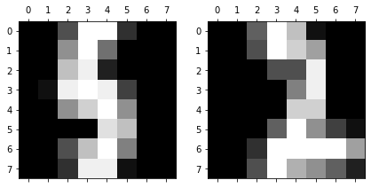

```python
# Prepare scoring payload.
job_payload = {
    client.deployments.ScoringMetaNames.INPUT_DATA: [{
        'values': [list(score_data[0]), list(score_data[1])]
    }]
}

f, (ax1, ax2) = plt.subplots(1, 2, figsize=(7,4))
ax = [ax1, ax2]

for i in range (len(ax)):
    plt.gray()
    ax[i].matshow(np.array(job_payload['input_data'][0]['values'][i]).reshape((8, 8)))
```

Use the `client.deployments.score()` method to run the scoring.

```python
# Perform prediction and display the result.
job_details = client.deployments.score(deployment_uid,job_payload)
pprint(job_details)
```

```
{'predictions': [{'fields': ['prediction'], 'values': [[5], [2]]}]}
```

The model had predicted the numbers `5` and `2` respectively.

```python
digits.target[int(0.9*samples_count):int(0.9*samples_count)+2]
```

```
array([5, 2])
```

As you can see the model has succesfully predicted the values.

### 5.4 Delete the deployment

Use the following method to delete the deployment.

```python
# Delete deployment.
client.deployments.delete(deployment_uid)
```

```
'SUCCESS'
```

You can check if your deployment has deleted successfully by generating a list of your saved deployments:

```python
# List the deployments.
client.deployments.list()
```

```
----  ----  -----  -------  -------------
GUID  NAME  STATE  CREATED  ARTIFACT_TYPE
----  ----  -----  -------  -------------
```

### 5.5 Delete the model

```python
# Delete model.
client.repository.delete(model_uid)
```

```
'SUCCESS'
```

You can check if your model has deleted successfully by generating a list of your saved models:

```python
# List the models.
client.repository.list_models()
```

```
----  ----  -------  ----
GUID  NAME  CREATED  TYPE
----  ----  -------  ----
```

## 6. Summary and next steps

You successfully completed this notebook!

You learned how to use the scikit-learn machine learning as well as the Watson Machine Learning (WML) API client for model creation and deployment.

### Resources

To learn more about configurations used in this notebook or more sample notebooks, tutorials, documentation, how-tos, and blog posts, check out these links:

#### IBM documentation

[watson-machine-learning](https://wml-api-pyclient-dev-v4.mybluemix.net)

[CP4D 2.5](https://www.ibm.com/support/knowledgecenter/SSQNUZ_current/wsj/getting-started/welcome-main.html)

#### IBM Samples

[Sample notebooks](https://github.com/IBMDataScience/sample-notebooks)

#### Others

[Official Python website](https://www.python.org)

[Matplotlib: Python plotting](https://matplotlib.org)

[scikit-learn: Grid Search](https://scikit-learn.org/stable/modules/generated/sklearn.model_selection.GridSearchCV.html)

### Authors

**Wojciech Sobala** is a Data Scientist at IBM developing enterprise-level applications that substantially increases clients' ability to turn data into actionable knowledge.  
**Ananya Kaushik** is a Data Scientist at IBM.

Copyright © 2017-2019 IBM. This notebook and its source code are released under the terms of the MIT License.

Love this notebook? Don't have an account yet?  
Share it with your colleagues and help them discover the power of Watson Studio! [Sign Up](https://ibm.co/wsnotebooks)